# GISP all drugs

Scott Olesen

# Antibiotic use

I group drugs into classes:

- macolides (azi, clarithro, erythro)
- quinolones (*xacin)
- celaphosporins (cef-, ceph-)
- tetracyclines (*cycline)
- penicillins (amox, amox/clav, pen v, amp, diclox, pen g)

By eye, it looks like there are seasonal patterns:

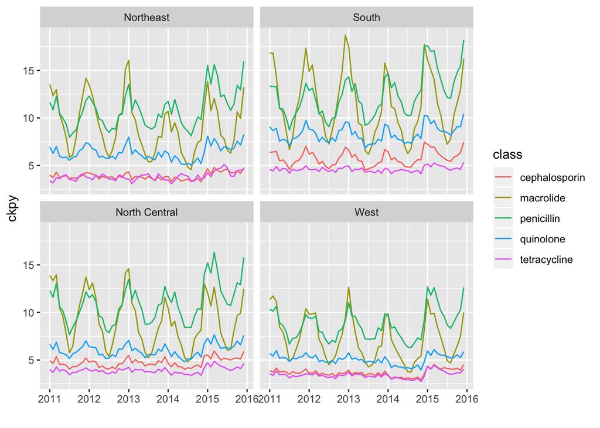

But there is also something fishy about the 2014-2015 merged: use seems to go up for all drugs, especially in the West. This might introduce some weird effects in the wavelet analysis.

## Wavelet analysis

To detect seasonality of antibiotic use, I do a wavelet analysis. I exclude the 2015 data because of the weird 2014-2015 jump, which introduces some weird stuff into the wavelets.

Dotted lines show 12 month periods. (The Northeast/tetracyclines has an extra line for 6 month period.) Solid black lines show regions with $p < 0.05$. Shaded areas along the side are the “cone of influence” where edge effects are important.

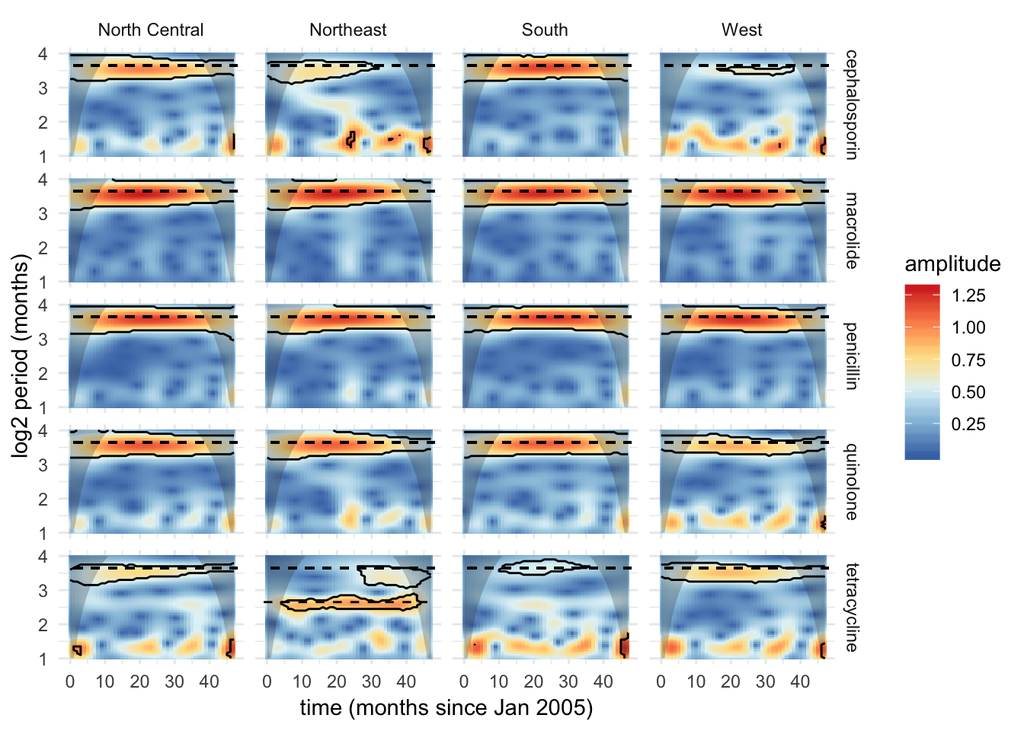

- In general, macrolides, penicillins, and quinolones are highly seasonal.
- Cephalosporins are seasonal in the South and North Central (i.e., Midwest) and much less so in the Northeast and West.
- Tetracyclines are weakly seasonal in North Central and West. In the Northeast, there is a 6-monthly seasonality.

## Sinusoidal fits

Sinusoidal fits to use data

| class | region | amplitude | amplitude_sig | peak |
| --- | --- | --- | --- | --- |
| macrolide | Northeast | 3.381 | TRUE | 0.112 |
| macrolide | South | 4.427 | TRUE | -0.121 |
| macrolide | North Central | 3.413 | TRUE | 0.027 |
| macrolide | West | 2.848 | TRUE | 0.458 |
| penicillin | Northeast | 1.785 | TRUE | 0.450 |
| penicillin | South | 2.325 | TRUE | 0.058 |
| penicillin | North Central | 2.089 | TRUE | 0.274 |
| penicillin | West | 1.629 | TRUE | 0.637 |
| quinolone | Northeast | 0.603 | TRUE | -0.115 |
| quinolone | South | 0.876 | TRUE | -0.281 |
| quinolone | North Central | 0.607 | TRUE | -0.260 |
| quinolone | West | 0.284 | TRUE | 0.477 |
| cephalosporin | Northeast | 0.139 | TRUE | 0.541 |
| cephalosporin | South | 0.865 | TRUE | -0.003 |
| cephalosporin | North Central | 0.361 | TRUE | 0.072 |
| cephalosporin | West | 0.128 | FALSE | 0.718 |
| tetracycline | Northeast | 0.146 | FALSE | 5.203 |
| tetracycline | South | 0.144 | TRUE | 0.882 |
| tetracycline | North Central | 0.193 | TRUE | 0.482 |
| tetracycline | West | 0.210 | TRUE | 1.161 |

Use of every drug is yearly-seasonal, except for cephalosporins in the West and tetracyclines in the Northeast. I expect the Northeast tet thing has something to do with the 6-month cycle.

### Tetracyclines

When looking just at the tetracycline drugs, it’s clear that minocycline (used to treat acne) is stable through the year, while doxycycline (used to treat Lyme disease, among other things) has more complicated seasonal dynamics:

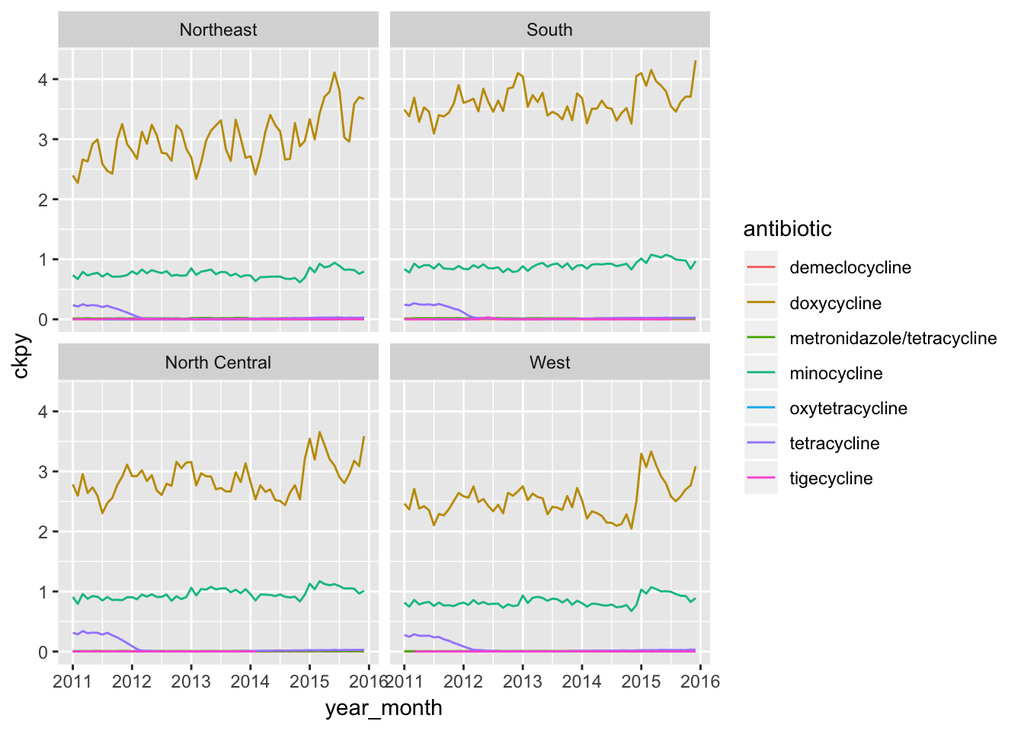

# Resistance

## Model fit

It might make sense to do models for each drug/region combination, since for some drugs it seems like use patterns vary by region.